# QK Box 10.5

We show several ways to approach this data set, ranging from the “traditional” OLS nested analysis to simplified analysis using means, to linear mixed models and REML/ML. At this stage, it’s useful to show you the ways you might encounter these analyses, but in practice you’d use one.

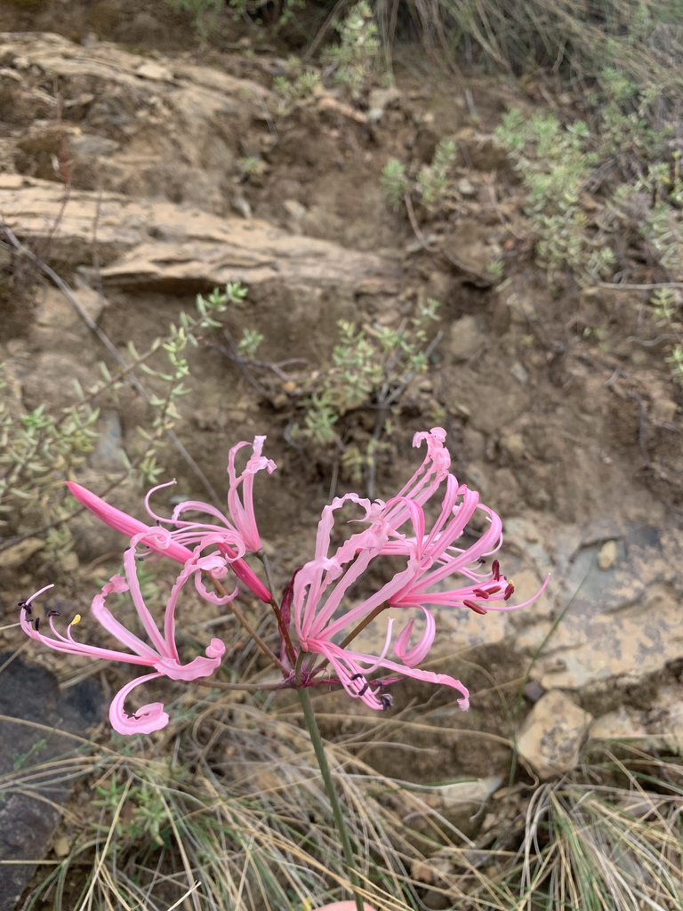

*Nerine humilis*. Sam McCarren , via iNaturalist. There’s also a good picture of the different phenotypes as Figure 1 of Newman et al.

The paper is [here](https://doi.org/10.1111/evo.12736), and the data are at [dryad](https://datadryad.org/stash/dataset/doi:10.5061/dryad.c8fb1), as an Excel file *floral_traits nested ANOVA* and we’ve used the *tepal length* sheet for this example*.*

Newman, E., Manning, J. & Anderson, B. (2015). Local adaptation: Mechanical fit between floral ecotypes of *Nerine humilis* (Amaryllidaceae) and pollinator communities. *Evolution*, 69, 2262-75.

### Preliminaries

First, load the required packages (afex, car, lattice, lme4, lmerTest, nlme, VCA, Rmisc)

Import newman data file (newman_tepal.csv)

```r
newman_tepal <- read.csv("../data/newman_tepal.csv")
head(newman_tepal,10)
```

|  | population | phenotype | tepal | population1 |
| --- | --- | --- | --- | --- |
| 1 | 1 | Short | 26.08 | a |
| 2 | 1 | Short | 20.04 | a |
| 3 | 1 | Short | 18.70 | a |
| 4 | 1 | Short | 21.04 | a |
| 5 | 1 | Short | 16.42 | a |
| 6 | 1 | Short | 18.26 | a |
| 7 | 1 | Short | 23.92 | a |
| 8 | 1 | Short | 17.81 | a |
| 9 | 1 | Short | 24.83 | a |
| 10 | 1 | Short | 22.44 | a |

Make population a factor

```r
newman_tepal$population <- factor(newman_tepal$population)
```

Calculate summary stats by groups

```r
newman_sum <- summarySE(newman_tepal,measurevar='tepal', groupvars= c('population','phenotype'))
newman_sum
```

| population | phenotype | N | tepal | sd | se | ci |
| --- | --- | --- | --- | --- | --- | --- |
| 1 | Short | 20 | 20.80350 | 2.581693 | 0.5772841 | 1.208270 |
| 2 | Short | 21 | 18.86905 | 4.582447 | 0.9999719 | 2.085905 |
| 3 | Short | 27 | 20.64815 | 3.914507 | 0.7533471 | 1.548527 |
| 4 | Short | 20 | 21.60500 | 3.570971 | 0.7984935 | 1.671266 |
| 5 | Short | 23 | 21.45652 | 4.397605 | 0.9169641 | 1.901667 |
| 6 | Short | 19 | 29.42105 | 4.497725 | 1.0318489 | 2.167834 |
| 7 | Short | 43 | 24.94186 | 4.465755 | 0.6810213 | 1.374357 |
| 9 | Long | 22 | 29.92227 | 5.719689 | 1.2194419 | 2.535968 |
| 10 | Long | 26 | 29.50000 | 4.420407 | 0.8669132 | 1.785441 |
| 11 | Long | 25 | 29.08000 | 3.946729 | 0.7893457 | 1.629129 |

do preliminary checks (look OK)

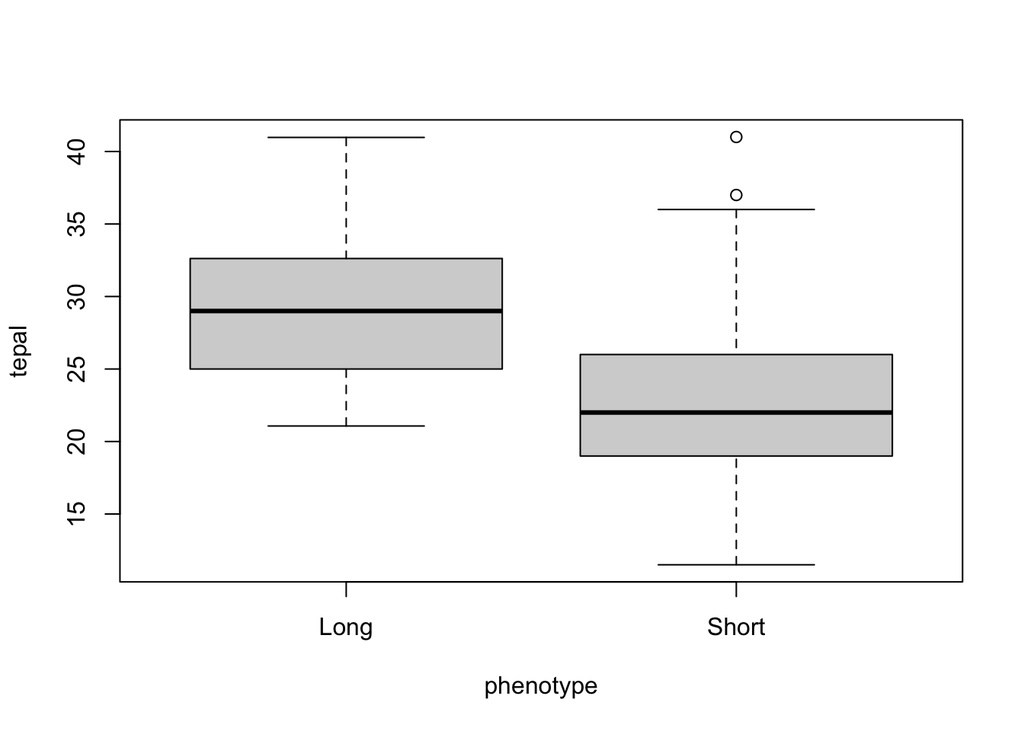

```r
boxplot(tepal~phenotype, data=newman_tepal)
```

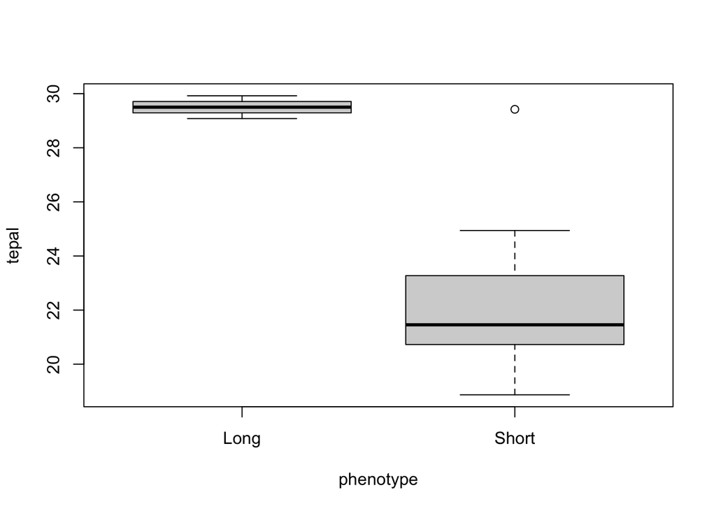

```r
boxplot(tepal~phenotype, data=newman_sum)
```

## Fit nested anova model

Note: Defaults to Type I SS in *R* - can’t change it with nested aov structures. Need to get Type III from another package (e.g. spss) - very similar to Type I and II anyway

```r
newman.aov <- aov(tepal~phenotype+Error(population), newman_tepal)
```

Plot residuals based on colonies

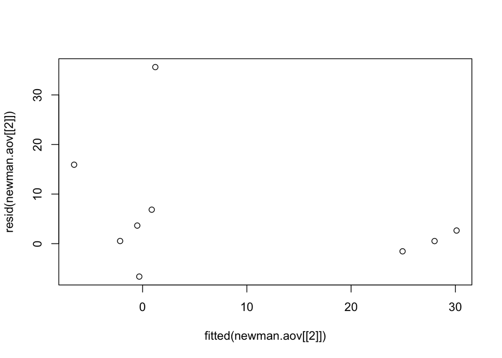

```r
plot(resid(newman.aov[[2]])~fitted(newman.aov[[2]]))
```

### Get anova summary

```r
options(digits=3)
summary(newman.aov)
```

```
##
## Error: population
##           Df Sum Sq Mean Sq F value Pr(>F)
## phenotype  1   2363    2363    11.6 0.0094 **
## Residuals  8   1636     205
## ---
## Signif. codes:  0 '***' 0.001 '**' 0.01 '*' 0.05 '.' 0.1 ' ' 1
##
## Error: Within
##            Df Sum Sq Mean Sq F value Pr(>F)
## Residuals 236   4364    18.5
```

### Use lm command as an alternative

```r
newman.lm1 <- lm(tepal~phenotype+phenotype/population, newman_tepal)
summary(newman.lm1)
```

```
##
## Call:
## lm(formula = tepal ~ phenotype + phenotype/population, data = newman_tepal)
##
## Residuals:
##    Min     1Q Median     3Q    Max
## -8.852 -2.965 -0.222  2.864 11.579
##
## Coefficients: (10 not defined because of singularities)
##                             Estimate Std. Error t value Pr(>|t|)
## (Intercept)                   29.080      0.860   33.81  < 2e-16 ***
## phenotypeShort                -8.277      1.290   -6.42  7.6e-10 ***
## phenotypeLong:population2         NA         NA      NA       NA
## phenotypeShort:population2    -1.934      1.344   -1.44  0.15124
## phenotypeLong:population3         NA         NA      NA       NA
## phenotypeShort:population3    -0.155      1.269   -0.12  0.90264
## phenotypeLong:population4         NA         NA      NA       NA
## phenotypeShort:population4     0.802      1.360    0.59  0.55614
## phenotypeLong:population5         NA         NA      NA       NA
## phenotypeShort:population5     0.653      1.315    0.50  0.61986
## phenotypeLong:population6         NA         NA      NA       NA
## phenotypeShort:population6     8.618      1.378    6.26  1.8e-09 ***
## phenotypeLong:population7         NA         NA      NA       NA
## phenotypeShort:population7     4.138      1.164    3.56  0.00046 ***
## phenotypeLong:population9      0.842      1.257    0.67  0.50348
## phenotypeShort:population9        NA         NA      NA       NA
## phenotypeLong:population10     0.420      1.205    0.35  0.72763
## phenotypeShort:population10       NA         NA      NA       NA
## phenotypeLong:population11        NA         NA      NA       NA
## phenotypeShort:population11       NA         NA      NA       NA
## ---
## Signif. codes:  0 '***' 0.001 '**' 0.01 '*' 0.05 '.' 0.1 ' ' 1
##
## Residual standard error: 4.3 on 236 degrees of freedom
## Multiple R-squared:  0.478,  Adjusted R-squared:  0.458
## F-statistic:   24 on 9 and 236 DF,  p-value: <2e-16
```

```r
anova(newman.lm1)
```

|  | Df | Sum Sq | Mean Sq | F value | Pr(>F) |
| --- | --- | --- | --- | --- | --- |
| phenotype | 1 | 2363 | 2363.0 | 127.8 | 5.78e-24 |
| phenotype:population | 8 | 1636 | 204.5 | 11.1 | 3.02e-13 |
| Residuals | 236 | 4364 | 18.5 | NA | NA |

```r
Anova(newman.lm1, type="II")
```

```
## Note: model has aliased coefficients
##       sums of squares computed by model comparison
```

|  | Sum Sq | Df | F value | Pr(>F) |
| --- | --- | --- | --- | --- |
| phenotype | 2363 | 1 | 127.8 | 5.78e-24 |
| phenotype:population | 1636 | 8 | 11.1 | 3.02e-13 |
| Residuals | 4364 | 236 | NA | NA |

```r
1-pf(11.060, 8, 236, lower.tail = TRUE, log.p = FALSE)
```

```
## [1] 3.02e-13
```

This output is treating populations as a fixed effect, so to show comparability with the initial nested effect, we need to recalculate the test for phenotype, using populations as the denominator.

```r
f <- 127.8/11.1
f
```

```
## [1] 11.5
```

```r
1-pf(f, 1, 8, lower.tail = TRUE, log.p = FALSE)
```

```
## [1] 0.00946
```

## Demonstrate nested is similar to one-way on colony means

```r
newman.aov2 <- aov(tepal~phenotype, newman_sum)
summary(newman.aov2)
```

```
##             Df Sum Sq Mean Sq F value Pr(>F)
## phenotype    1  101.9   101.9    10.8  0.011 *
## Residuals    8   75.6     9.4
## ---
## Signif. codes:  0 '***' 0.001 '**' 0.01 '*' 0.05 '.' 0.1 ' ' 1
```

Analysis using means won’t be exactly the same because sample sizes vary among populations.

### Variance components using VCA package

```r
newman.vca <- anovaMM(tepal~phenotype/(population), newman_tepal)
```

```
## Convert variable phenotype from "character" to "factor"!
```

```r
newman.vca
```

```
##
##
## ANOVA-Type Estimation of Mixed Model:
## --------------------------------------
##
##  [Fixed Effects]
##
##            int  phenotypeLong phenotypeShort
##          22.54           6.96           0.00
##
##
##  [Variance Components]
##
##   Name                 DF        SS          MS         VC        %Total
## 1 total                67.087549                        26.148709 100
## 2 phenotype:population 8         1636.057375 204.507172 7.657816  29.285635
## 3 error                236       4363.850882 18.490894  18.490894 70.714365
##   SD       CV[%]
## 1 5.113581 20.692506
## 2 2.767276 11.197999
## 3 4.300104 17.400708
##
## Mean: 24.7 (N = 246)
##
## Experimental Design: unbalanced  |  Method: ANOVA
```

```r
VCAinference(newman.vca, alpha=0.05, VarVC=TRUE, ci.method="satterthwaite")
```

```
##
##
##
## Inference from Mixed Model Fit
## ------------------------------
##
## > VCA Result:
## -------------
##
##  [Fixed Effects]
##
##            int  phenotypeLong phenotypeShort
##          22.54           6.96           0.00
##
##
##  [Variance Components]
##
##   Name                 DF      SS        MS       VC      %Total  SD
## 1 total                67.0875                    26.1487 100     5.1136
## 2 phenotype:population 8       1636.0574 204.5072 7.6578  29.2856 2.7673
## 3 error                236     4363.8509 18.4909  18.4909 70.7144 4.3001
##   CV[%]   Var(VC)
## 1 20.6925 21.1677
## 2 11.198  18.5087
## 3 17.4007 2.8976
##
## Mean: 24.7 (N = 246)
##
## Experimental Design: unbalanced  |  Method: ANOVA
##
##
## > VC:
## -----
##                      Estimate     DF CI LCL CI UCL One-Sided LCL One-Sided UCL
## total                   26.15  67.09  19.15   37.9         20.12          35.6
## phenotype:population     7.66   6.62   3.29   33.5          3.75          25.9
## error                   18.49 236.00  15.56   22.3         15.99          21.7
##
## > SD:
## -----
##                      Estimate     DF CI LCL CI UCL One-Sided LCL One-Sided UCL
## total                    5.11  67.09   4.38   6.15          4.49          5.97
## phenotype:population     2.77   6.62   1.81   5.79          1.94          5.09
## error                    4.30 236.00   3.94   4.73          4.00          4.65
##
## > CV[%]:
## --------
##                      Estimate     DF CI LCL CI UCL One-Sided LCL One-Sided UCL
## total                    20.7  67.09  17.71   24.9         18.15          24.2
## phenotype:population     11.2   6.62   7.34   23.4          7.84          20.6
## error                    17.4 236.00  15.96   19.1         16.18          18.8
##
##
## 95% Confidence Level
## Satterthwaite methodology used for computing CIs
```

## Mixed model using lme4

```r
newman.reml <- lmer(tepal~phenotype + (1|population), newman_tepal)
summary(newman.reml)
```

```
## Linear mixed model fit by REML. t-tests use Satterthwaite's method [
## lmerModLmerTest]
## Formula: tepal ~ phenotype + (1 | population)
##    Data: newman_tepal
##
## REML criterion at convergence: 1434
##
## Scaled residuals:
##     Min      1Q  Median      3Q     Max
## -2.0493 -0.6346 -0.0382  0.6484  2.8575
##
## Random effects:
##  Groups     Name        Variance Std.Dev.
##  population (Intercept)  8.45    2.91
##  Residual               18.50    4.30
## Number of obs: 246, groups:  population, 10
##
## Fixed effects:
##                Estimate Std. Error    df t value Pr(>|t|)
## (Intercept)       29.50       1.75  7.79   16.83  2.1e-07 ***
## phenotypeShort    -6.96       2.10  7.80   -3.32    0.011 *
## ---
## Signif. codes:  0 '***' 0.001 '**' 0.01 '*' 0.05 '.' 0.1 ' ' 1
##
## Correlation of Fixed Effects:
##             (Intr)
## phentypShrt -0.836
```

```r
newman.ml <- lmer(tepal~phenotype + (1|population), newman_tepal, REML=F)
summary(newman.ml)
```

```
## Linear mixed model fit by maximum likelihood . t-tests use Satterthwaite's
##   method [lmerModLmerTest]
## Formula: tepal ~ phenotype + (1 | population)
##    Data: newman_tepal
##
##      AIC      BIC   logLik deviance df.resid
##     1446     1460     -719     1438      242
##
## Scaled residuals:
##     Min      1Q  Median      3Q     Max
## -2.0468 -0.6475 -0.0484  0.6600  2.8986
##
## Random effects:
##  Groups     Name        Variance Std.Dev.
##  population (Intercept)  6.56    2.56
##  Residual               18.50    4.30
## Number of obs: 246, groups:  population, 10
##
## Fixed effects:
##                Estimate Std. Error    df t value Pr(>|t|)
## (Intercept)       29.50       1.56  9.67   18.87    6e-09 ***
## phenotypeShort    -6.96       1.87  9.69   -3.72   0.0042 **
## ---
## Signif. codes:  0 '***' 0.001 '**' 0.01 '*' 0.05 '.' 0.1 ' ' 1
##
## Correlation of Fixed Effects:
##             (Intr)
## phentypShrt -0.836
```

CI on variance components (remembering to square CIs from lmer with are in SD units)

```r
newman.ci <- confint.merMod(newman.reml)
```

```
## Computing profile confidence intervals ...
```

```r
newman.vc <- (newman.ci)^2
print(newman.vc)
```

```
##                 2.5 %  97.5 %
## .sig01           2.58   19.90
## .sigma          15.53   22.29
## (Intercept)    681.62 1081.82
## phenotypeShort 121.40    8.45
```

Test fixed effect using likelihood ratio tests

```r
newman.lme <- lmer(tepal~phenotype + (1|population), newman_tepal, REML=F)
newman.lme1 <- lmer(tepal~(1|population), newman_tepal, REML=F)
anova(newman.lme,newman.lme1)
```

|  | npar | AIC | BIC | logLik | deviance | Chisq | Df | Pr(>Chisq) |
| --- | --- | --- | --- | --- | --- | --- | --- | --- |
| newman.lme1 | 3 | 1453 | 1464 | -724 | 1447 | NA | NA | NA |
| newman.lme | 4 | 1446 | 1460 | -719 | 1438 | 8.65 | 1 | 0.00327 |

### Using lmerTest

```r
summary(newman.reml)
```

```
## Linear mixed model fit by REML. t-tests use Satterthwaite's method [
## lmerModLmerTest]
## Formula: tepal ~ phenotype + (1 | population)
##    Data: newman_tepal
##
## REML criterion at convergence: 1434
##
## Scaled residuals:
##     Min      1Q  Median      3Q     Max
## -2.0493 -0.6346 -0.0382  0.6484  2.8575
##
## Random effects:
##  Groups     Name        Variance Std.Dev.
##  population (Intercept)  8.45    2.91
##  Residual               18.50    4.30
## Number of obs: 246, groups:  population, 10
##
## Fixed effects:
##                Estimate Std. Error    df t value Pr(>|t|)
## (Intercept)       29.50       1.75  7.79   16.83  2.1e-07 ***
## phenotypeShort    -6.96       2.10  7.80   -3.32    0.011 *
## ---
## Signif. codes:  0 '***' 0.001 '**' 0.01 '*' 0.05 '.' 0.1 ' ' 1
##
## Correlation of Fixed Effects:
##             (Intr)
## phentypShrt -0.836
```

Get more reliable F-test than original anova for fixed effect based on Satterthwaite’s (default) and Kenward-Roger’s adjustment to df

```r
anova(newman.reml)
```

|  | Sum Sq | Mean Sq | NumDF | DenDF | F value | Pr(>F) |
| --- | --- | --- | --- | --- | --- | --- |
| phenotype | 204 | 204 | 1 | 7.8 | 11 | 0.0109 |

```r
anova(newman.reml, ddf="Kenward-Roger")
```

|  | Sum Sq | Mean Sq | NumDF | DenDF | F value | Pr(>F) |
| --- | --- | --- | --- | --- | --- | --- |
| phenotype | 204 | 204 | 1 | 7.97 | 11 | 0.0106 |